# lab_1_gd

Gabriel De La Rosa

1/9/2020

Read in fisheries data

```r
us_landings <- read_csv(here("data", "noaa_fisheries.csv")) %>%
  clean_names()
```

Let’s clean this data frame up so it’s tidy…

How do we get rid of the dollar sign? tidyr::separate() then as.numeric()… or readr::parse_number()

parse_number is awesome! use it within a mutate() parse_number only displays 7 sig figs, but doesn’t actually get rid of any digits

```r
landings_tidy <- us_landings %>%
  mutate(state = str_to_lower(state),
         afs_name = str_to_lower(afs_name)) %>%
  mutate(dollars_usd = (parse_number(dollars_usd,
                      na = c("NA"))))
```

Let’s just get some salmon information…

How do we remove data that we don’t want, aka the aggregate species data? Use str_remove, and then specify by the string you want it to recognize. Careful, though, better have a good reason for ignoring that… jk this doesn’t remove data, just the word…

We want data for just salmon. how do we filter by strings? use str_detect() If you use it in the beginning of a filter function, it only keeps things with that string.

How do we separate species from salmon? we can use separate()

```r
salmon_landings <- landings_tidy %>%
  mutate(afs_clean = str_remove(afs_name, " aggregate")) %>%
  filter(str_detect(afs_clean, patter = "salmon")) %>%
  separate(afs_clean, into = c("group", "species"), sep = ",")
```

Find some grouped summary data:

let’s find the annual total US landings and dollar value, summing across all states, for each TYPE of salmon using `group_by()` and `summarize()`

```r
salmon_summary <- salmon_landings %>%
  group_by(year, species) %>%
  summarize(
    tot_landings = sum(landings_pounds),
    tot_value = sum(dollars_usd))
```

Make a graph…

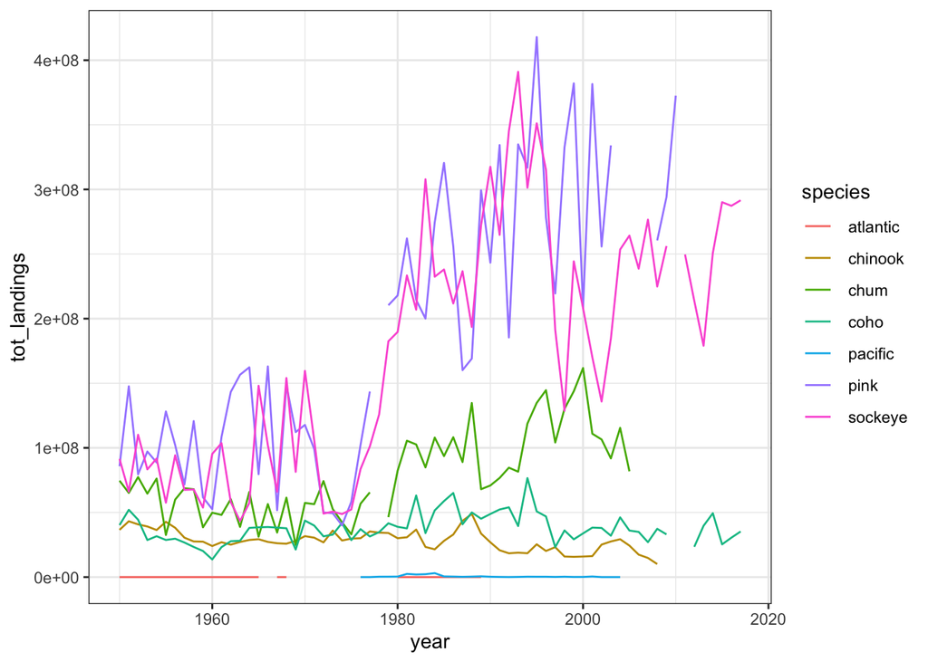

```r
salmon_landings_graph <-
  ggplot(salmon_summary, aes(x = year, y = tot_landings)) +
  geom_line(aes(color = species)) +
  theme_bw()

salmon_landings_graph
```

Now we can export our graph with ggsave()

```r
ggsave(plot = salmon_landings_graph,
       here("figures", "us_salmon_gd.png"),
       height = 5,
       width = 8)
```

Let’s make a nice Kable table…

```r
salmon_first_5 <- salmon_summary %>%
  head(5)
```

```r
kable(salmon_first_5) %>%
  kable_styling(bootstrap_options = "striped",
                full_width = FALSE)
```

| year | species | tot_landings | tot_value |
| --- | --- | --- | --- |
| 1950 | atlantic | 800 | 362 |
| 1950 | chinook | 36559160 | 8328433 |
| 1950 | chum | 74610432 | 5920158 |
| 1950 | coho | 40224632 | 7151008 |
| 1950 | pink | 85773432 | 6773180 |